# Data Wrangling

Karel Kroeze <k.a.kroeze@utwente.nl>  
September 21st, 2021

### Overview

# reading data

# tidyverse

# tidy data

# mutations

# transformations

# imputations

## Reading data

### Reading data - point & click

[figure not shown]

```r
train <- read.csv("D:/Synced/OneDrive/University of Twente/BDSI - General/Data Science Week/data/train.csv")
```

- Simple
- Effective
- limited to common data types
- Not very portable (absolute path)
  - easy to manually tweak

### Reading data - code

```r
train <- readr::read_csv("data/train.csv")
```

- Simple
- Effective
- Portable (relative path)
- there's a package for every data type

## See also:

- [haven](https://haven.tidyverse.org/) for SPSS, Stata, and SAS data,
- [readxl](https://readxl.tidyverse.org/) or [openxlsx](https://cran.r-project.org/web/packages/openxlsx/) for Excel spreadsheets,
- rvest for web scraping,

and [various other packages](https://www.tidyverse.org/packages/#import) for importing all sorts of data.

## Tidyverse

### Tidyverse

## Data is **messy**

- different sources, different formats, units, spellings…
- missing data
- structured, semi-structured, unstructured

## R is **messy**

- technical debt
- lots of packages, lots of authors

## Tidyverse is… **tidy**

- an **opinionated** set of packages for data science
- shared philosophy, design, grammar and data structure

## Tidy data is an **opinion**

- is it “right”?  
  *usually*
- is it useful?  
  *absolutely*
- used in University of Twente education
- used by BDSi data scientists *but we're fine with messy when it's convenient!*

## See also

- https://www.tidyverse.org/
- https://r4ds.had.co.nz/

## Tidy Data

### Tidy Data?

```r
table1
```

```
# A tibble: 6 x 4
  country      year  cases population
  <chr>       <int>  <int>      <int>
1 Afghanistan  1999    745   19987071
2 Afghanistan  2000   2666   20595360
3 Brazil       1999  37737  172006362
4 Brazil       2000  80488  174504898
5 China        1999 212258 1272915272
6 China        2000 213766 1280428583
```

```r
table2
```

```
# A tibble: 12 x 4
   country      year type            count
   <chr>       <int> <chr>           <int>
 1 Afghanistan  1999 cases             745
 2 Afghanistan  1999 population   19987071
 3 Afghanistan  2000 cases            2666
 4 Afghanistan  2000 population   20595360
 5 Brazil       1999 cases           37737
 6 Brazil       1999 population  172006362
 7 Brazil       2000 cases           80488
 8 Brazil       2000 population  174504898
 9 China        1999 cases          212258
10 China        1999 population 1272915272
11 China        2000 cases          213766
12 China        2000 population 1280428583
```

```r
table3
```

```
# A tibble: 6 x 3
  country      year rate
* <chr>       <int> <chr>
1 Afghanistan  1999 745/19987071
2 Afghanistan  2000 2666/20595360
3 Brazil       1999 37737/172006362
4 Brazil       2000 80488/174504898
5 China        1999 212258/1272915272
6 China        2000 213766/1280428583
```

```r
table4a
```

```
# A tibble: 3 x 3
  country     `1999` `2000`
* <chr>        <int>  <int>
1 Afghanistan    745   2666
2 Brazil       37737  80488
3 China       212258 213766
```

```r
table4b
```

```
# A tibble: 3 x 3
  country         `1999`     `2000`
* <chr>            <int>      <int>
1 Afghanistan   19987071   20595360
2 Brazil       172006362  174504898
3 China       1272915272 1280428583
```

### Tidy Data

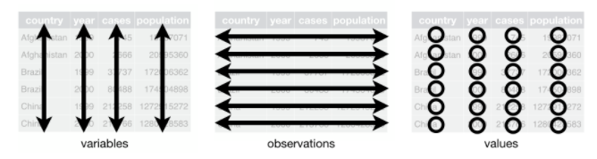

- each **column** is a **variable**
- each **row** is an **observation**
- each **cell** is a **value**

### Tidy Data?

```r
test_results
```

```
# A tibble: 10 x 7
   student  res_meth_1 res_meth_2 lin_meth_1 lin_meth_2 math_stat_1 math_stat_2
   <glue>        <dbl> <lgl>           <dbl>      <dbl>       <dbl>       <dbl>
 1 s1597662        7.3 NA                6.5       NA           8.3        NA
 2 s2055581        8.5 NA                7.8       NA           5.6         6.6
 3 s1793478        7.8 NA                7.4       NA           5.8         6.7
 4 s2286296        7.4 NA                5.5        5.2         6.1        NA
 5 s1609104        7.3 NA                6.1       NA           6.4        NA
 6 s1895328        6.5 NA                8.6       NA           6.1        NA
 7 s1935686        8.8 NA                4.8        6.5         4.2         6.2
 8 s1834364       10   NA                9.1       NA           7.2        NA
 9 s1893532        7.5 NA                6.3       NA           5.2         7.4
10 s1707982        9.8 NA                4.4        6.6         5.8         6.7
```

### Tidy Data?

```r
test_results %>%
    rowwise() %>%
    transmute(
        student,
        res_meth = max(
            c_across(contains("res")),
            na.rm=TRUE),
        lin_meth = max(
            c_across(contains("lin")),
            na.rm=TRUE),
        math_stat = max(
            c_across(contains("stat")),
            na.rm=TRUE)
    )
```

```
# A tibble: 10 x 4
# Rowwise:
   student  res_meth lin_meth math_stat
   <glue>      <dbl>    <dbl>     <dbl>
 1 s1597662      7.3      6.5       8.3
 2 s2055581      8.5      7.8       6.6
 3 s1793478      7.8      7.4       6.7
 4 s2286296      7.4      5.5       6.1
 5 s1609104      7.3      6.1       6.4
 6 s1895328      6.5      8.6       6.1
 7 s1935686      8.8      6.5       6.2
 8 s1834364     10        9.1       7.2
 9 s1893532      7.5      6.3       7.4
10 s1707982      9.8      6.6       6.7
```

```r
test_results %>%
    rowwise() %>%
    transmute(
        student,
        res_meth = max(
            c_across(contains("res")),
            na.rm=TRUE),
        lin_meth = max(
            c_across(contains("lin")),
            na.rm=TRUE),
        math_stat = max(
            c_across(contains("stat")),
            na.rm=TRUE)
    ) %>%
    pivot_longer(
        -student,
        names_to="course",
        values_to="grade"
    )
```

```
# A tibble: 30 x 3
   student  course    grade
   <glue>   <chr>     <dbl>
 1 s1597662 res_meth    7.3
 2 s1597662 lin_meth    6.5
 3 s1597662 math_stat   8.3
 4 s2055581 res_meth    8.5
 5 s2055581 lin_meth    7.8
 6 s2055581 math_stat   6.6
 7 s1793478 res_meth    7.8
 8 s1793478 lin_meth    7.4
 9 s1793478 math_stat   6.7
10 s2286296 res_meth    7.4
# ... with 20 more rows
```

### Tidy data?

```r
test_results %>%
    pivot_longer(
        -student,
        names_to=c("course", "attempt"),
        names_pattern="(.*)_(\\d+)",
        values_to="result",
        values_drop_na=TRUE
    )
```

```
# A tibble: 38 x 4
   student  course    attempt result
   <glue>   <chr>     <chr>    <dbl>
 1 s1597662 res_meth  1          7.3
 2 s1597662 lin_meth  1          6.5
 3 s1597662 math_stat 1          8.3
 4 s2055581 res_meth  1          8.5
 5 s2055581 lin_meth  1          7.8
 6 s2055581 math_stat 1          5.6
 7 s2055581 math_stat 2          6.6
 8 s1793478 res_meth  1          7.8
 9 s1793478 lin_meth  1          7.4
10 s1793478 math_stat 1          5.8
# ... with 28 more rows
```

```r
test_results %>%
    pivot_longer(
        -student,
        names_to=c("course", "attempt"),
        names_pattern="(.*)_(\\d+)",
        values_to="result",
        values_drop_na=TRUE
    ) %>%
    group_by(student, course) %>%
    summarize(grade = max(result))
```

```
# A tibble: 30 x 3
# Groups:   student [10]
   student  course    grade
   <glue>   <chr>     <dbl>
 1 s1597662 lin_meth    6.5
 2 s1597662 math_stat   8.3
 3 s1597662 res_meth    7.3
 4 s1609104 lin_meth    6.1
 5 s1609104 math_stat   6.4
 6 s1609104 res_meth    7.3
 7 s1707982 lin_meth    6.6
 8 s1707982 math_stat   6.7
 9 s1707982 res_meth    9.8
10 s1793478 lin_meth    7.4
# ... with 20 more rows
```

## Housing Data

### Housing Data

```r
train <- readr::read_csv("data/train.csv")
train
```

```
# A tibble: 1,460 x 81
      Id MSSubClass MSZoning LotFrontage LotArea Street Alley LotShape
   <dbl>      <dbl> <chr>          <dbl>   <dbl> <chr>  <chr> <chr>
 1     1         60 RL                65    8450 Pave   <NA>  Reg
 2     2         20 RL                80    9600 Pave   <NA>  Reg
 3     3         60 RL                68   11250 Pave   <NA>  IR1
 4     4         70 RL                60    9550 Pave   <NA>  IR1
 5     5         60 RL                84   14260 Pave   <NA>  IR1
 6     6         50 RL                85   14115 Pave   <NA>  IR1
 7     7         20 RL                75   10084 Pave   <NA>  Reg
 8     8         60 RL                NA   10382 Pave   <NA>  IR1
 9     9         50 RM                51    6120 Pave   <NA>  Reg
10    10        190 RL                50    7420 Pave   <NA>  Reg
# ... with 1,450 more rows, and 73 more variables: LandContour <chr>,
#   Utilities <chr>, LotConfig <chr>, LandSlope <chr>, Neighborhood <chr>,
#   Condition1 <chr>, Condition2 <chr>, BldgType <chr>, HouseStyle <chr>,
#   OverallQual <dbl>, OverallCond <dbl>, YearBuilt <dbl>, YearRemodAdd <dbl>,
#   RoofStyle <chr>, RoofMatl <chr>, Exterior1st <chr>, Exterior2nd <chr>,
#   MasVnrType <chr>, MasVnrArea <dbl>, ExterQual <chr>, ExterCond <chr>,
#   Foundation <chr>, BsmtQual <chr>, BsmtCond <chr>, BsmtExposure <chr>, ...
```

### Housing Data

```r
test <- readr::read_csv("data/test.csv")
test
```

```
# A tibble: 1,459 x 80
      Id MSSubClass MSZoning LotFrontage LotArea Street Alley LotShape
   <dbl>      <dbl> <chr>          <dbl>   <dbl> <chr>  <chr> <chr>
 1  1461         20 RH                80   11622 Pave   <NA>  Reg
 2  1462         20 RL                81   14267 Pave   <NA>  IR1
 3  1463         60 RL                74   13830 Pave   <NA>  IR1
 4  1464         60 RL                78    9978 Pave   <NA>  IR1
 5  1465        120 RL                43    5005 Pave   <NA>  IR1
 6  1466         60 RL                75   10000 Pave   <NA>  IR1
 7  1467         20 RL                NA    7980 Pave   <NA>  IR1
 8  1468         60 RL                63    8402 Pave   <NA>  IR1
 9  1469         20 RL                85   10176 Pave   <NA>  Reg
10  1470         20 RL                70    8400 Pave   <NA>  Reg
# ... with 1,449 more rows, and 72 more variables: LandContour <chr>,
#   Utilities <chr>, LotConfig <chr>, LandSlope <chr>, Neighborhood <chr>,
#   Condition1 <chr>, Condition2 <chr>, BldgType <chr>, HouseStyle <chr>,
#   OverallQual <dbl>, OverallCond <dbl>, YearBuilt <dbl>, YearRemodAdd <dbl>,
#   RoofStyle <chr>, RoofMatl <chr>, Exterior1st <chr>, Exterior2nd <chr>,
#   MasVnrType <chr>, MasVnrArea <dbl>, ExterQual <chr>, ExterCond <chr>,
#   Foundation <chr>, BsmtQual <chr>, BsmtCond <chr>, BsmtExposure <chr>, ...
```

- one variable less in test data…
  - can you guess which?

### Outcome :: Sale Price

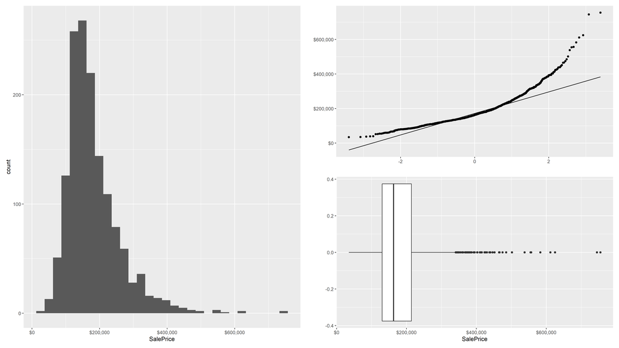

Strongly skewed -> Log transform?

### Outcome :: log(SalePrice)

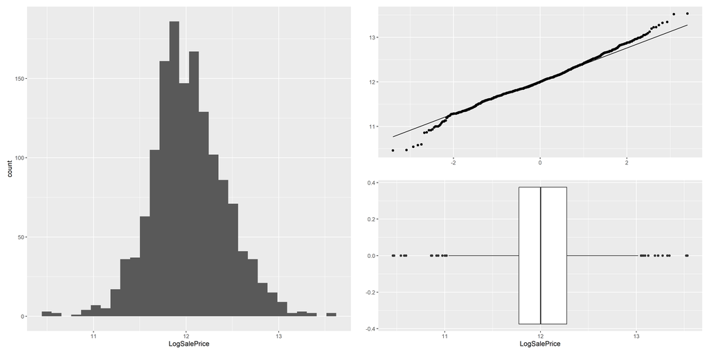

```r
library(magrittr) # %<>% operator

train %<>% mutate(LogSalePrice = log(SalePrice))
```

Much better!

### Inputs :: Transformations

- Check distributions
- Apply transformations where necessary
  - centralization
  - normalization
  - log, square root, etc.
- **Anna** will talk more about why in thursdays' **Modelling** workshop
- for simplicity, I will (mostly) skip transformations
  - that assumes everything is nicely distributed
  - you should *never* assume, always check

### Inputs :: Missing Data

```r
tibble(
    column = colnames(train),
    missing = train %>% map_dbl(~is.na(.) %>% mean())
) %>%
    arrange(-missing) %>%
    filter(missing > .05)
```

```
# A tibble: 11 x 2
   column       missing
   <chr>          <dbl>
 1 PoolQC        0.995
 2 MiscFeature   0.963
 3 Alley         0.938
 4 Fence         0.808
 5 FireplaceQu   0.473
 6 LotFrontage   0.177
 7 GarageType    0.0555
 8 GarageYrBlt   0.0555
 9 GarageFinish  0.0555
10 GarageQual    0.0555
11 GarageCond    0.0555
```

- Mostly related to features
  - pool, “misc”, fence, fireplace, garage
- Alley?
- LotFrontage is 'real' missing data?

### Missing Data :: Mutate

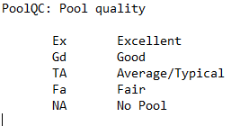

```r
train$PoolQC %>% table()
```

```
.
Ex Fa Gd
 2  2  3
```

```r
train$PoolArea %>% table()
```

```
.
   0  480  512  519  555  576  648  738
1453    1    1    1    1    1    1    1
```

- Very few observations
  - can't use as linear/ordinal inputs
  - might be enough for a dichotomous input?
  - (still sketchy at best)

```r
train %<>%
    mutate(Pool = !is.na(PoolQC)) %>%
    select(-PoolQC, -PoolArea)
```

```r
train$Pool %>% summary()
```

```
   Mode   FALSE    TRUE
logical    1453       7
```

Still **very** unbalanced

### Missing Data :: Mutate(2)

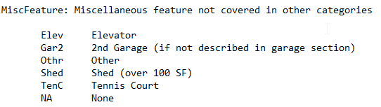

- It's **Other** all the way down…

```r
train$MiscFeature %>% table()
```

```
.
Gar2 Othr Shed TenC
   2    2   49    1
```

- **Shed** is probably worth picking up

```r
train %<>%
    mutate(
        Shed = !is.na(MiscFeature) & MiscFeature == "Shed",
        ShedArea = ifelse(Shed, MiscVal, NA)) %>%
    select(-MiscFeature, -MiscVal)
```

```r
train %>% select(contains("Shed"))
```

```
# A tibble: 1,460 x 2
   Shed  ShedArea
   <lgl>    <dbl>
 1 FALSE       NA
 2 FALSE       NA
 3 FALSE       NA
 4 FALSE       NA
 5 FALSE       NA
 6 TRUE       700
 7 FALSE       NA
 8 TRUE       350
 9 FALSE       NA
10 FALSE       NA
# ... with 1,450 more rows
```

```r
train$Shed %>% summary()
```

```
   Mode   FALSE    TRUE
logical    1411      49
```

### Missing Data :: Split Variables

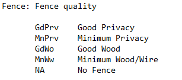

```r
train$Fence %>% table()
```

```
.
GdPrv  GdWo MnPrv  MnWw
   59    54   157    11
```

```r
train %<>%
    separate(
        Fence,
        sep = 2, # number of characters before split
        into = c("FenceQuality", "FenceType"),
        remove = FALSE) %>%
    mutate(
        FenceType = recode(
            FenceType,
            Prv = "Privacy",
            Wo = "WoodOrWire",
            Ww = "WoodOrWire"),
        FenceQuality = recode(
            FenceQuality,
            Gd = "Good",
            Mn = "Minimum"),
        Fence = !is.na(Fence))
```

```r
train %>% select(starts_with("Fence"))
```

```
# A tibble: 1,460 x 3
   Fence FenceQuality FenceType
   <lgl> <chr>        <chr>
 1 FALSE <NA>         <NA>
 2 FALSE <NA>         <NA>
 3 FALSE <NA>         <NA>
 4 FALSE <NA>         <NA>
 5 FALSE <NA>         <NA>
 6 TRUE  Minimum      Privacy
 7 FALSE <NA>         <NA>
 8 FALSE <NA>         <NA>
 9 FALSE <NA>         <NA>
10 FALSE <NA>         <NA>
# ... with 1,450 more rows
```

```r
train$Fence %>% summary()
```

```
   Mode   FALSE    TRUE
logical    1179     281
```

### Missing Data :: Imputation

“**LotFrontage**: Linear feet of street connected to property”

- probably depends on…
  - neighborhood
  - lot area
- let's try to impute based on those factors
- We need to **normalize** before fitting the model
  - for simplicity, I'm assuming all the usual assumptions are met

```r
# define a helper function for normalization
normalize <- function(x) {
    (x - mean(x, na.rm = T)) / sd(x, na.rm = T)
}

# apply normalize across multiple columns
train %<>% mutate(
    across(c(LotFrontage, LotArea), normalize)
)

# fit a multilevel model
library(lme4)
mlm <- lmer(
    LotFrontage ~ LotArea + (1|Neighborhood),
    data = train)
LotFrontage_Predictions <- predict(mlm, train)
```

```r
summary(mlm)
```

```
Linear mixed model fit by REML ['lmerMod']
Formula: LotFrontage ~ LotArea + (1 | Neighborhood)
   Data: train

REML criterion at convergence: 3033.8

Scaled residuals:
    Min      1Q  Median      3Q     Max
-7.0025 -0.4698 -0.0912  0.3670 10.7888

Random effects:
 Groups       Name        Variance Std.Dev.
 Neighborhood (Intercept) 0.2928   0.5411
 Residual                 0.6886   0.8298
Number of obs: 1201, groups:  Neighborhood, 25

Fixed effects:
            Estimate Std. Error t value
(Intercept) -0.18717    0.11407  -1.641
LotArea      0.44506    0.03227  13.791

Correlation of Fixed Effects:
        (Intr)
LotArea 0.018
```

```r
# coalesce picks first non-missing value
train %<>% mutate(
    LotFrontage = coalesce(
        LotFrontage,
        LotFrontage_Predictions))
```

### Missing Data :: Homework

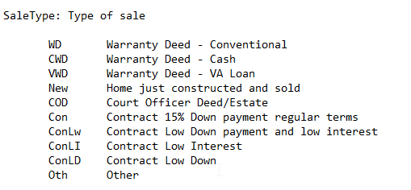

- How many different variables are combined here?
- Do you know what all these levels mean?
- Are there more **Frankenstein'ed** variables like this?

### N'Sync

- Apply the same transformations to training and testing data!
- it's probably a good idea to **merge** the data before wrangling  
  (I forgot, and I'm too lazy to go back now…)

```r
data <- bind_rows(
    train = train,
    test = test,
    .id = "source"
)
data %>% dim()
```

```
[1] 2919   82
```

- apply transformations on the *complete* data set

```r
data %<>% mutate( ... ) # and so forth...
```

- we can then split the data again when we're ready

```r
data %>% filter(source == "train") %>% dim()
```

```
[1] 1460   82
```

```r
data %>% filter(source == "test") %>% dim()
```

```
[1] 1459   82
```

## Next Steps

### Next Steps

# Cheat Sheets

- incredibly helpful
- nothing to be ashamed of
- built into RStudio  
  Help -> Cheat Sheets
- on my christmas wish list  
  to decorate our new office!

## See https://www.rstudio.com/resources/cheatsheets/

### Next Steps

# Modelling

- We've made a start preparing the data for modelling
- Continue with…
  - applying transformations where needed
  - deal with missing data
  - remove 'defective' or irrelevant columns
  - combine columns to create new features

# Join us on **thursday** for the workshop!

- complete modelling pipeline
  - use **tidymodels** to simplify wrangling
- feature selection
- fitting and tuning models
- assessing model performance

### Next Steps

# Visualization

- We already made some simple plots for distributions
- We may want to visualize…
  - relations between variables
  - differences between (sub)groups (e.g. neighborhood)
  - predicted sales price
  - effect of various inputs
  - … and much more

# Join us on **friday** for the workshop!

- More examples with **ggplot2**
  - more layers, facets, etc.
- Simple interactive plots with **plotly**
- **shiny** plots - limited only by your imagination
  - and time  
    *mostly time*